# Projet

Guillaume Picard and Jean Bernard NDONGO AMBASSA

06/01/2020

```r
library(readr)
library(tidyverse)
library(ggmap)
library(dplyr)
```

Chargement du fichier dans la variable data frame (dfr)

```r
dfr <- read_csv("US Mass Shootings.csv")
```

1.2 - Complétez les valeurs manquantes des variables “Latitude” et “Longitude” en utilisant les informations de la variable “Lieu”. Complétez également ce dernier.

```r
install.packages("jsonlite")
#Require the package so you can use it
require("jsonlite")
infoTana <- jsonlite::fromJSON("https://nominatim.openstreetmap.org/reverse?format=jsonv2&lat=41.878114&lon=-87.629798")

baseUrl <- "https://nominatim.openstreetmap.org/search/@"
endUrl <- "@?adressdetails=0&format=json"
reverseBaseUrl <- "https://nominatim.openstreetmap.org/reverse?format=jsonv2&lat="
reverseEndUrl <- "&lon="
for(i in 1:nrow(dfr))
{
  if(is.na(dfr$Longitude[i]) || is.na(dfr$Latitude[i]))
  {
     url <- paste(baseUrl,gsub(' [A-z ]*', '',dfr$Location[i]),sep = "")
     url <- paste(url,endUrl,sep = "")
     info <- jsonlite::fromJSON(url)
     for(j in 1:nrow(dfr))
     {
       if(grepl("United", info$display_name[j])){
         dfr$Longitude[i] <- info$lon[j]
         dfr$Latitude[i] <- info$lat[j]
       }
     }

  }
  else if(is.na(dfr$Location[i])){
    urlreverse <- paste(reverseBaseUrl,dfr$Latitude[i],sep = "")
    urlreverse <- paste(urlreverse,reverseEndUrl,sep = "")
    urlreverse <- paste(urlreverse,dfr$Longitude[i],sep="")
    infoReverse <- jsonlite::fromJSON(urlreverse)
    test <- infoReverse$address
    infoReverse$address
    if(grepl( "United States",infoReverse$address$country)){

      if(!is.null(infoReverse$address$city)){
        dfr$Location[i] <- infoReverse$address$city
      }
      else if(!is.null(infoReverse$address$hamlet))
      {
         dfr$Location[i] <- infoReverse$address$hamlet
      }
      else if(!is.null(infoReverse$address$village)){
        dfr$Location[i] <- infoReverse$address$village
      }
      else{
         dfr$Location[i] <- infoReverse$address$road
      }

    }

  }
}
```

1.3 - Séparez la variable “Date” en trois variables “Jour”, “Mois”, “Année”. Convertissez les deux premiers en chaînes, avec des valeurs le nom du jour et le nom du mois. La variable “Année” sera numérique.

```r
 dfr <- dfr %>%  separate(Date, sep = "/" ,into = c("month", "day", "year"))
```

1.4 - Supprimez les doublons et facilitez une analyse plus approfondie en effectuant un regroupement intelligent des valeurs pour les variables catégorielles suivantes: “Sexe”, “Race”, “Problèmes de santé mentale”, “Ouvrir / fermer l’emplacement” et “Cause”. Facultatif: faites la même chose pour les variables “Cible”, “Zone d’incident” et “Type d’arme”.

```r
dfr %>%
  select(Gender) %>%
  group_by(Gender) %>%
  summarise(nb = n()) %>%
  arrange(-nb)
```

```
## # A tibble: 6 x 2
##   Gender         nb
##   <chr>       <int>
## 1 Male          264
## 2 Unknown        21
## 3 M              20
## 4 Female          5
## 5 Male/Female     3
## 6 M/F             1
```

```r
dfr %>%
  select(Race) %>%
  group_by(Race) %>%
  summarise(nb = n()) %>%
  arrange(-nb)
```

```
## # A tibble: 18 x 2
##    Race                                                   nb
##    <chr>                                               <int>
##  1 White American or European American                   119
##  2 Black American or African American                     75
##  3 Unknown                                                41
##  4 Some other race                                        19
##  5 white                                                  11
##  6 Asian American                                         10
##  7 White                                                   9
##  8 Asian                                                   6
##  9 Black                                                   5
## 10 Latino                                                  5
## 11 Native American or Alaska Native                        3
## 12 black                                                   2
## 13 Other                                                   2
## 14 Two or more races                                       2
## 15 <NA>                                                    2
## 16 Asian American/Some other race                          1
## 17 Black American or African American/Unknown              1
## 18 White American or European American/Some other Race     1
```

```r
dfr %>%
  select(`Mental Health Issues`) %>%
  group_by(`Mental Health Issues`) %>%
  summarise(nb = n()) %>%
  arrange(-nb)
```

```
## # A tibble: 5 x 2
##   `Mental Health Issues`    nb
##   <chr>                  <int>
## 1 Unknown                  106
## 2 Yes                      103
## 3 No                        91
## 4 Unclear                   13
## 5 unknown                    1
```

```r
dfr %>%
  select(`Open/Close Location`) %>%
  group_by(`Open/Close Location`) %>%
  summarise(nb = n()) %>%
  arrange(-nb)
```

```
## # A tibble: 6 x 2
##   `Open/Close Location`    nb
##   <chr>                 <int>
## 1 Close                   211
## 2 Open                     79
## 3 Open+Close               19
## 4 Unknown                   3
## 5 Open+CLose                1
## 6 <NA>                      1
```

```r
dfr %>%
  select(Cause) %>%
  group_by(Cause) %>%
  summarise(nb = n()) %>%
  arrange(-nb)
```

```
## # A tibble: 17 x 2
##    Cause                   nb
##    <chr>                <int>
##  1 <NA>                    77
##  2 psycho                  64
##  3 terrorism               61
##  4 anger                   44
##  5 frustration             18
##  6 domestic dispute        12
##  7 unemployement           10
##  8 revenge                  9
##  9 racism                   6
## 10 unknown                  4
## 11 failing exams            3
## 12 breakup                  1
## 13 domestic disputer        1
## 14 drunk                    1
## 15 religious radicalism     1
## 16 robbery                  1
## 17 suspension               1
```

```r
dfr %>%
  select(`Incident Area`) %>%
  group_by(`Incident Area`) %>%
  summarise(nb = n()) %>%
  arrange(-nb)
```

```
## # A tibble: 175 x 2
##    `Incident Area`      nb
##    <chr>             <int>
##  1 <NA>                 60
##  2 Home                 42
##  3 Workplace             8
##  4 Home+School           7
##  5 Church                5
##  6 Club                  4
##  7 street                4
##  8 School                3
##  9 Shopping Mall         3
## 10 Apartment Complex     2
## # … with 165 more rows
```

```r
dfr %>%
  select(Target) %>%
  group_by(Target) %>%
  summarise(nb = n()) %>%
  arrange(-nb)
```

```
## # A tibble: 55 x 2
##    Target               nb
##    <chr>             <int>
##  1 random              137
##  2 Family               36
##  3 Coworkers            17
##  4 Students             16
##  5 Students+Teachers    14
##  6 Ex-Coworkers          9
##  7 party guests          7
##  8 Ex-Wife               6
##  9 coworkers             5
## 10 Policeman             5
## # … with 45 more rows
```

```r
dfr %>%
  select(`Weapon Type`) %>%
  group_by(`Weapon Type`) %>%
  summarise(nb = n()) %>%
  arrange(-nb)
```

```
## # A tibble: 26 x 2
##    `Weapon Type`                                            nb
##    <chr>                                                 <int>
##  1 Unknown                                                 199
##  2 Semi-automatic Handgun                                   31
##  3 Handgun                                                  21
##  4 Semi-automatic Rifle                                     11
##  5 Semi-automatic Rifle, Semi-automatic Handgun             10
##  6 Semi-automatic Handgun, Handgun                           6
##  7 Semi-automatic Rifle, Semi-automatic Handgun, Shotgun     6
##  8 Shotgun                                                   5
##  9 Handgun, Shotgun                                          4
## 10 Semi-automatic Handgun, Shotgun                           3
## # … with 16 more rows
```

INITIATIVE : Pour une meilleure visibilité des données que nous utiliserons ultérieurement, nous regrouperons les valeurs relatives au GENRE, à la COURSE, à LA CONDITION MENTALE et au LIEU DES CRIMES dans les noms communs.

```r
for(i in 1:nrow(dfr))
{
  if(dfr$Gender[i] == "M")
  {
    dfr$Gender[i] <- "Male"
  }
  else if(dfr$Gender[i] == "M/F")
  {
    dfr$Gender[i] <- "Male/Female"
  }

}

for(i in 1:nrow(dfr))
{
  if(is.na(dfr$Race[i]) || dfr$Race[i] == "Some other race" || dfr$Race[i] == "Other" || dfr$Race[i] == "Two or more races")
  {
    dfr$Race[i] <- "Unknown"
  }
 else if(dfr$Race[i] == "white" || dfr$Race[i] == "White" || dfr$Race[i] =="White American or European American/Some other Race")
  {
    dfr$Race[i] <- "White American or European American"
  }
 else if(dfr$Race[i] == "Black" || dfr$Race[i] == "black"||dfr$Race[i] == "Black American or African American/Unknown")
  {
    dfr$Race[i] <- "Black American or African American"
  }
 else if(dfr$Race[i] == "Asian" || dfr$Race[i] == "Asian American/Some other race" )
  {
    dfr$Race[i] <- "Asian American"
  }
}

for(i in 1:nrow(dfr))
{
  if(dfr$`Mental Health Issues`[i] == "unknown" || dfr$`Mental Health Issues`[i] == "Unclear" )
  {
    dfr$`Mental Health Issues`[i] <- "Unknown"
  }
}


for(i in 1:nrow(dfr))
{

  if(is.na(dfr$`Open/Close Location`[i]))
  {
    dfr$`Open/Close Location`[i] <- "Unknown"
  }
  else if(dfr$`Open/Close Location`[i] == "Open+CLose")
  {
    dfr$`Open/Close Location`[i] <- "Open+Close"
  }
}
```

II- Etude des variables catégorielles.

2.1 - Ajoutez une variable catégorielle binaire, avec la valeur 1 si la variable “Total victimes” est supérieure ou égale à 10 et 0 sinon.

```r
  dfr[,"MoreThanTenKills"] <- NA
```

```r
for(i in 1:nrow(dfr))
{
  if(dfr$`Total victims`[i] >= 10)
  {
    dfr$MoreThanTenKills[i] <- 1
  }
  else{
    dfr$MoreThanTenKills[i] <- 0
  }
}
```

2.2 -Etudier individuellement les principales variables catégorielles

*Gender

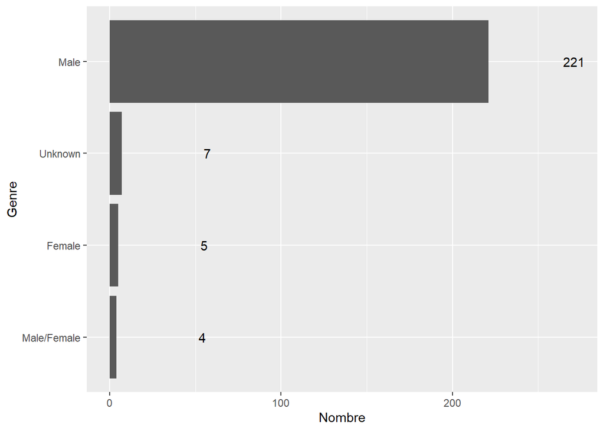

```r
dfrClean <- dfr[!is.na(dfr$Cause),]
dfrClean %>%
  group_by(Gender) %>%
  summarise(nb = n()) %>%
  arrange(-nb) %>%
  slice(1:10) %>%
  ggplot( aes(x = fct_reorder(Gender, nb), y = nb)) + #
  geom_col() +
  coord_flip() +
  geom_text(aes(x = fct_reorder(Gender, nb), y = nb + 50, label = nb) )+
  labs(x = "Genre", y = "Nombre")
```

```r
genre <- c(284,21,5,4)
#chisq.test(genre, p = c(1/4, 1/4, 1/4, 1/4))
chisq.test(genre, p = c(0.91, 0.03, 0.03,0.03))
```

```
##
##  Chi-squared test for given probabilities
##
## data:  genre
## X-squared = 19.438, df = 3, p-value = 0.0002219
```

```r
prop.test(genre,c(314,314,314,314))
```

```
##
##  4-sample test for equality of proportions without continuity
##  correction
##
## data:  genre out of c(314, 314, 314, 314)
## X-squared = 959.47, df = 3, p-value < 2.2e-16
## alternative hypothesis: two.sided
## sample estimates:
##     prop 1     prop 2     prop 3     prop 4
## 0.90445860 0.06687898 0.01592357 0.01273885
```

INTERPRETATION:

Tous ces résultats sont visibles grace au graphique effectué.

*RACE

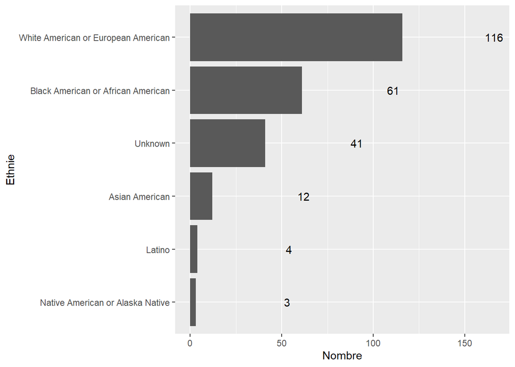

```r
dfrClean %>%
  group_by(Race) %>%
  summarise(nb = n()) %>%
  arrange(-nb) %>%
  slice(1:10) %>%
  ggplot( aes(x = fct_reorder(Race, nb), y = nb)) + #
  geom_col() +
  coord_flip() +
  geom_text(aes(x = fct_reorder(Race, nb), y = nb + 50, label = nb) )+
  labs(x = "Ethnie", y = "Nombre")
```

```r
race <- c(140,83,66,17,5,3)
chisq.test(race, p = c(1/6, 1/6, 1/6, 1/6, 1/6, 1/6))
```

```
##
##  Chi-squared test for given probabilities
##
## data:  race
## X-squared = 281.57, df = 5, p-value < 2.2e-16
```

```r
prop.test(race,c(314,314,314,314,314,314))
```

```
##
##  6-sample test for equality of proportions without continuity
##  correction
##
## data:  race out of c(314, 314, 314, 314, 314, 314)
## X-squared = 337.88, df = 5, p-value < 2.2e-16
## alternative hypothesis: two.sided
## sample estimates:
##     prop 1     prop 2     prop 3     prop 4     prop 5     prop 6
## 0.44585987 0.26433121 0.21019108 0.05414013 0.01592357 0.00955414
```

INTERPRETATION:

-Dans le test de chi 2 effectuer , l’hypothese null que nous posons est que il y’a une égalité entre les proportions des races.

-D’apres nos resultats , l’hypothese null n’est pas verifiée car la p-value obtenue est inferieur à 0.05

Tous ces résultats sont visibles grace au graphique realisé à cet effet.

*Mental Health Issues

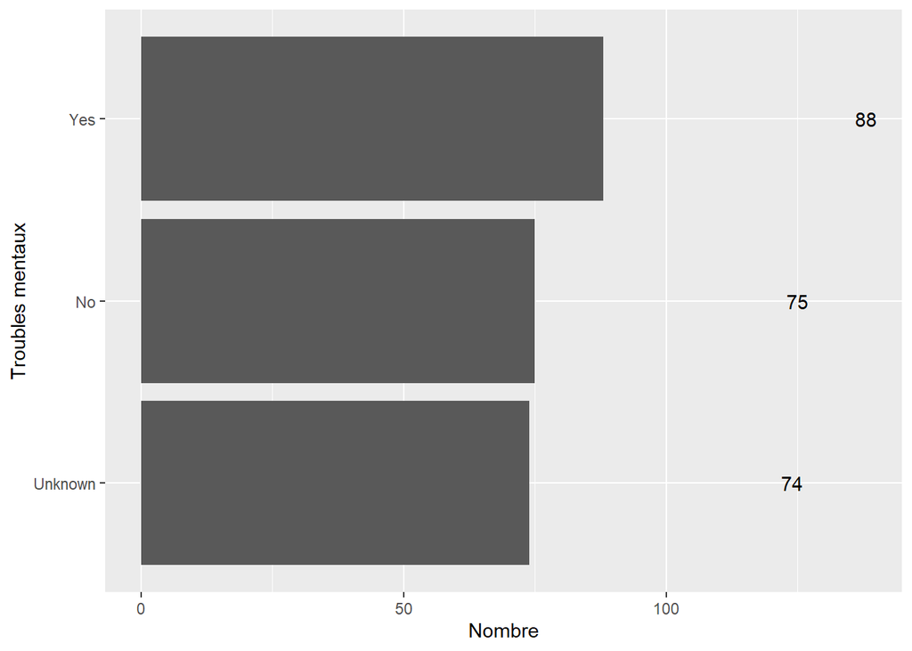

```r
dfrClean %>%
  group_by(`Mental Health Issues`) %>%
  summarise(nb = n()) %>%
  arrange(-nb) %>%
  slice(1:10) %>%
  ggplot( aes(x = fct_reorder(`Mental Health Issues`, nb), y = nb)) + #
  geom_col() +
  coord_flip() +
  geom_text(aes(x = fct_reorder(`Mental Health Issues`, nb), y = nb + 50, label = nb))+
  labs(x = "Troubles mentaux", y = "Nombre")
```

```r
mentalHealth <- c(120,103,91)
chisq.test(mentalHealth, p = c(1/3,1/3,1/3))
```

```
##
##  Chi-squared test for given probabilities
##
## data:  mentalHealth
## X-squared = 4.0573, df = 2, p-value = 0.1315
```

```r
prop.test(mentalHealth,c(314,314,314))
```

```
##
##  3-sample test for equality of proportions without continuity
##  correction
##
## data:  mentalHealth out of c(314, 314, 314)
## X-squared = 6.086, df = 2, p-value = 0.04769
## alternative hypothesis: two.sided
## sample estimates:
##    prop 1    prop 2    prop 3
## 0.3821656 0.3280255 0.2898089
```

INTERPRETATION:

-Dans le test de chi 2 effectué , l’hypothese null que nous posons est que il y’a une égalité entre les proportions de personne atteinte de maladie mentale et celle qui ne sont pas.

-D’apres nos resultats , l’hypothese null est verifiée car la p-value n’est pas inferieur à 0.05

-Pour le test de proportion il en ressort que nous avons 38.20.60% de personne donc l’état mental est inconnue, 32.80% de personnes souffrantes de maladie mentale, 29% de personnes saine mentalement.

*open/clause location

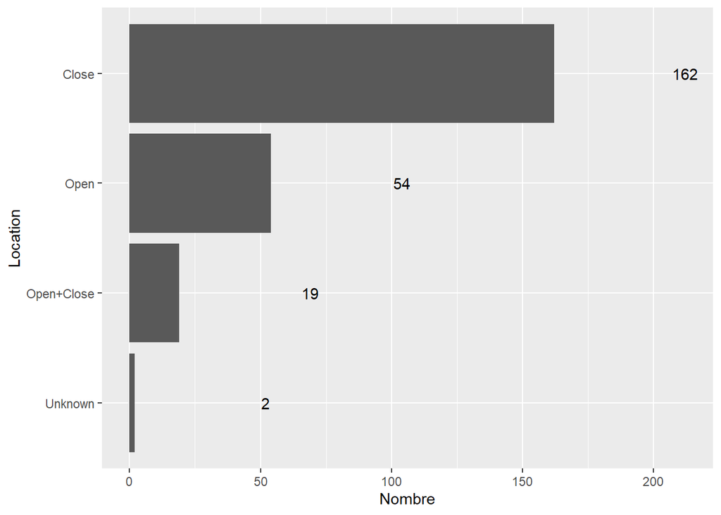

```r
dfrClean %>%
  group_by(`Open/Close Location`) %>%
  summarise(nb = n()) %>%
  arrange(-nb) %>%
  slice(1:10) %>%
  ggplot( aes(x = fct_reorder(`Open/Close Location`, nb), y = nb)) + #
  geom_col() +
  coord_flip() +
  geom_text(aes(x = fct_reorder(`Open/Close Location`, nb), y = nb + 50, label = nb))+
  labs(x = "Location", y = "Nombre")
```

```r
OpenClose <- c(211,79,20,4)
chisq.test(OpenClose, p = c(1/4,1/4,1/4, 1/4))
```

```
##
##  Chi-squared test for given probabilities
##
## data:  OpenClose
## X-squared = 337.95, df = 3, p-value < 2.2e-16
```

```r
prop.test(OpenClose,c(314,314,314,314))
```

```
##
##  4-sample test for equality of proportions without continuity
##  correction
##
## data:  OpenClose out of c(314, 314, 314, 314)
## X-squared = 450.6, df = 3, p-value < 2.2e-16
## alternative hypothesis: two.sided
## sample estimates:
##     prop 1     prop 2     prop 3     prop 4
## 0.67197452 0.25159236 0.06369427 0.01273885
```

INTERPRETATION:

-Dans le test de chi 2 effectué , l’hypothese null que nous posons est que il y’a une égalité entre les proportions des lieux où ont eu lieu des crimes.

-D’apres nos resultats , l’hypothese null n’est verifiée car la p-value est largement inferieur à 0.05

-Pour le test de proportion il en ressort que nous avons 67.20% des crimes qui sont commis dans des espaces fermés, 25.10% sont comis dans des espaces ouverts, 6.40% sont commis dans des espaces fermé / ouvert et 1.30% dans des espaces inconnues

Tous ces résultats sont visibles grace au graphique realisé à cet effet.

*cause // à faire

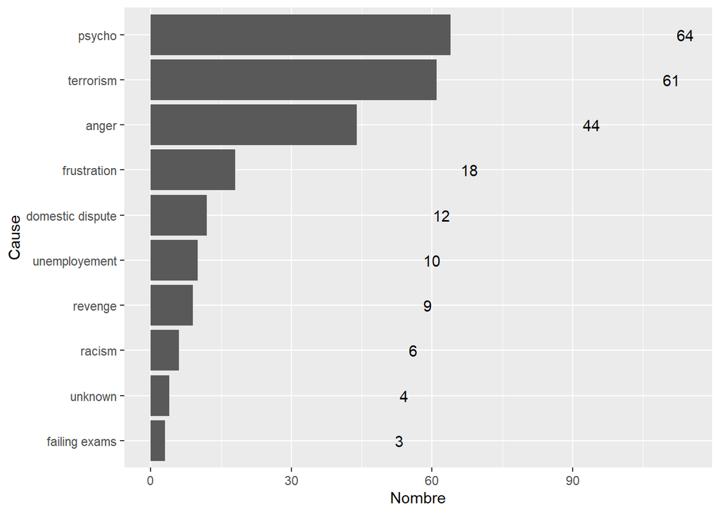

```r
dfrClean %>%
  group_by(Cause) %>%
  summarise(nb = n()) %>%
  arrange(-nb) %>%
  slice(1:10) %>%
  ggplot( aes(x = fct_reorder(Cause, nb), y = nb,label=)) + #
  geom_col() +
  coord_flip() +
  geom_text(aes(x = fct_reorder(Cause, nb), y = nb + 50, label = nb))+
  labs(x = "Cause", y = "Nombre")
```

```r
cause <- c(77,64,61,44,18,12,10,9,6,4)
prop.test(cause,c(314,314,314,314,314,314,314,314,314,314))
```

```
##
##  10-sample test for equality of proportions without continuity
##  correction
##
## data:  cause out of c(314, 314, 314, 314, 314, 314, 314, 314, 314, 314)
## X-squared = 257.12, df = 9, p-value < 2.2e-16
## alternative hypothesis: two.sided
## sample estimates:
##     prop 1     prop 2     prop 3     prop 4     prop 5     prop 6     prop 7
## 0.24522293 0.20382166 0.19426752 0.14012739 0.05732484 0.03821656 0.03184713
##     prop 8     prop 9    prop 10
## 0.02866242 0.01910828 0.01273885
```

INTERPRETATION:

-Pour le test de proportion il en ressort que nous avons 24.50% de meutres sont d’origines non repertoriés , 20.40% sont de causes psychologiques, 19.40% sont de causes téroristes , 14% sont du à la colère, 5.70% sont du à la frustration, 3.80% sont du aux disputes domestiques, 3.20% sont du au chomage, 2.90% sont du à des actes de vengeance, 1.90% sont du au racisme, 1.30% sont de cause inconnue.

Tous ces résultats sont visibles grace au graphique realisé à cet effet.

2.3 - Représenter les associations entre des paires de variables catégorielles (graphiques à barres empilées, graphiques à barres groupées, etc.).

- RACE / GENDER

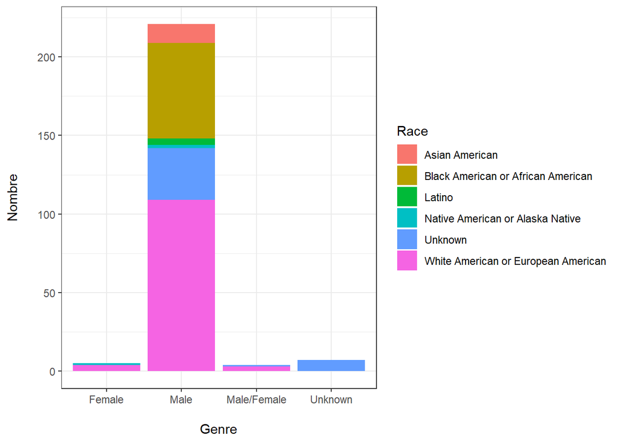

```r
library(ggplot2)
ggplot(dfrClean, aes(x = dfrClean$Gender, y = 1, fill = Race)) +
  geom_bar(stat = "identity") +
  xlab("\nGenre") +
  ylab("Nombre\n") +
  theme_bw()
```

INTERPRETATION:

- Ce graphe presente la repartition des races par rapport aux genres des individus et on peut y lire que les américain de race blanche et ceux d’origine europeenne y sont largement reprsentés, suivi de pres par les noirs americains ou ceux d’origine africaine et en troisieme position vienne les personnes d’origines inconnues. on peut potentiellement deduire que les americains de race blanche ou d’origine europpenne on une prédisposition à la violence par exemmle.

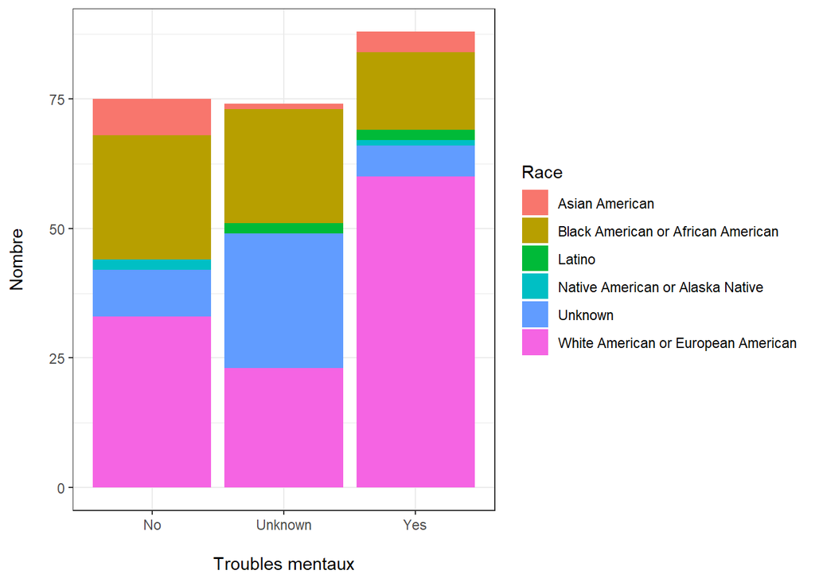

```r
ggplot(dfrClean, aes(x = dfrClean$`Mental Health Issues`, y = 1, fill = Race)) +
  geom_bar(stat = "identity") +
  xlab("\nTroubles mentaux") +
  ylab("Nombre\n") +
  theme_bw()
```

troubles metaux / genre

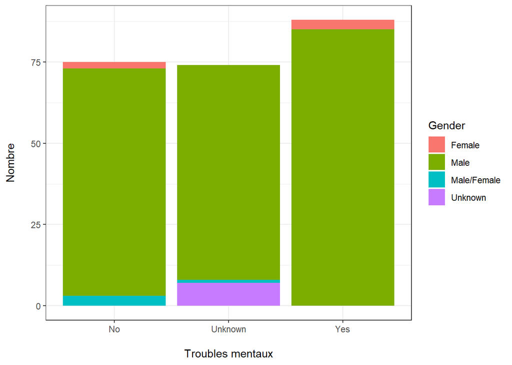

```r
ggplot(dfrClean, aes(x = dfrClean$`Mental Health Issues`, y = 1, fill = Gender)) +
  geom_bar(stat = "identity") +
  xlab("\nTroubles mentaux") +
  ylab("Nombre\n") +
  theme_bw()
```

race / cause

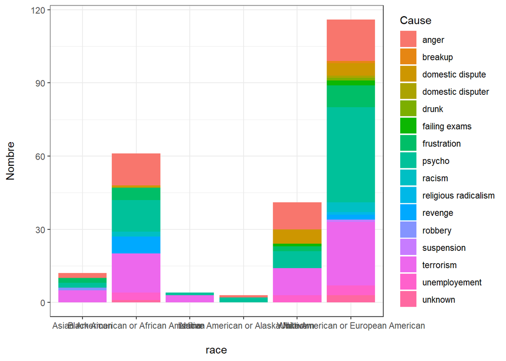

```r
ggplot(dfrClean, aes(x = dfrClean$Race, y = 1, fill = Cause)) +
  geom_bar(stat = "identity") +
  xlab("\nrace") +
  ylab("Nombre\n") +
  theme_bw()
```

INTERPRETATION: - Ce graphe represente la repartition par race des causes à l’origines des crimes aux USA. Il en ressort que les causes les plus frequentes de mortalité à savoir psychologique, la frustration, therorisme, chomage sont orchestrés par les americains de race blanche ou d’origines europeennes.

3 - Etude des variables quantitatives.

- Fatalities

```r
dfr %>%
  summary()
```

```
##        S#            Title             Location            State
##  Min.   :  1.00   Length:314         Length:314         Length:314
##  1st Qu.: 84.25   Class :character   Class :character   Class :character
##  Median :163.50   Mode  :character   Mode  :character   Mode  :character
##  Mean   :163.21
##  3rd Qu.:244.75
##  Max.   :323.00
##
##     month               day                year           Incident Area
##  Length:314         Length:314         Length:314         Length:314
##  Class :character   Class :character   Class :character   Class :character
##  Mode  :character   Mode  :character   Mode  :character   Mode  :character
##
##
##
##
##  Open/Close Location    Target             Cause             Summary
##  Length:314          Length:314         Length:314         Length:314
##  Class :character    Class :character   Class :character   Class :character
##  Mode  :character    Mode  :character   Mode  :character   Mode  :character
##
##
##
##
##    Fatalities        Injured       Total victims    Policeman Killed
##  Min.   : 0.000   Min.   :  0.00   Min.   :  3.00   Min.   :0.0000
##  1st Qu.: 1.000   1st Qu.:  1.00   1st Qu.:  4.00   1st Qu.:0.0000
##  Median : 3.000   Median :  3.00   Median :  5.00   Median :0.0000
##  Mean   : 4.379   Mean   :  6.15   Mean   : 10.18   Mean   :0.1104
##  3rd Qu.: 5.000   3rd Qu.:  5.00   3rd Qu.:  8.00   3rd Qu.:0.0000
##  Max.   :59.000   Max.   :527.00   Max.   :585.00   Max.   :5.0000
##                                                     NA's   :6
##       Age          Weapon Type        Mental Health Issues     Race
##  Min.   :   0.00   Length:314         Length:314           Length:314
##  1st Qu.:  20.00   Class :character   Class :character     Class :character
##  Median :  33.00   Mode  :character   Mode  :character     Mode  :character
##  Mean   :  79.09
##  3rd Qu.:  42.00
##  Max.   :1932.00
##  NA's   :139
##     Gender            Latitude          Longitude         MoreThanTenKills
##  Length:314         Length:314         Length:314         Min.   :0.0000
##  Class :character   Class :character   Class :character   1st Qu.:0.0000
##  Mode  :character   Mode  :character   Mode  :character   Median :0.0000
##                                                           Mean   :0.2134
##                                                           3rd Qu.:0.0000
##                                                           Max.   :1.0000
##
```

Represent associations between quantitative variables and categorical variables total victims / race

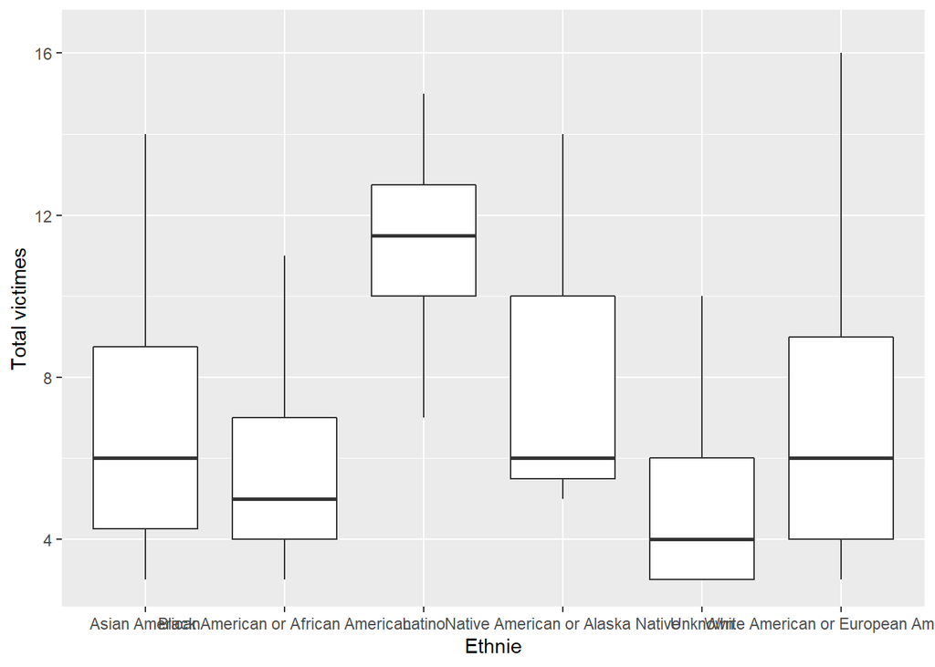

```r
ggplot(dfrClean, aes(x=dfrClean$Race, y=dfrClean$`Total victims`)) +
   geom_boxplot(outlier.shape = NA) +
  scale_y_continuous(limits = quantile(dfrClean$`Total victims`, c(0.1, 0.9)))+
  labs(x = "Ethnie", y = "Total victimes")
```

age / race

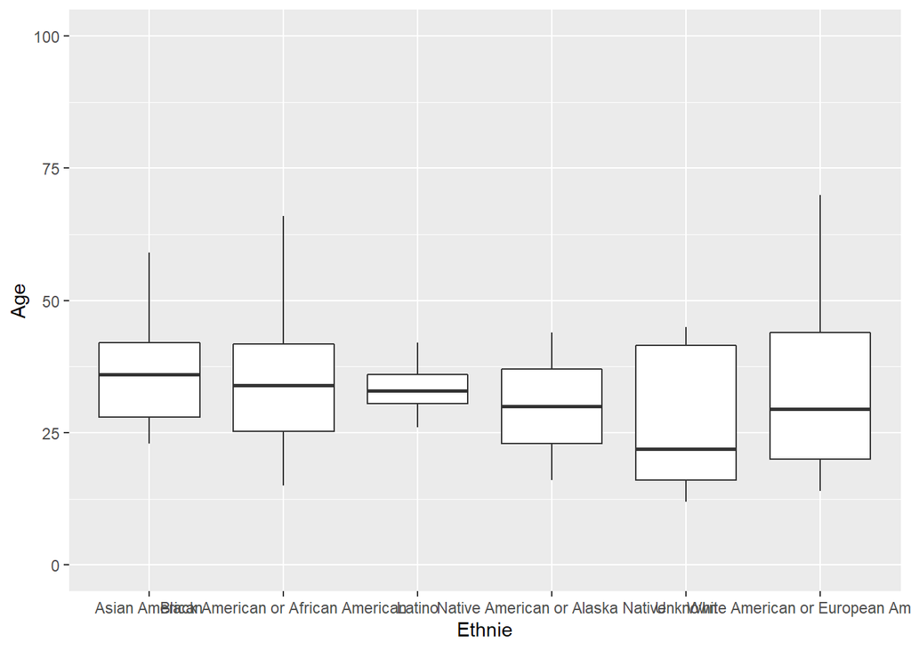

```r
ggplot(dfrClean, aes(x=dfrClean$Race, y=dfrClean$Age)) +
   geom_boxplot(outlier.shape = NA) +
   coord_cartesian(ylim = c(0, 100))+
  labs(x = "Ethnie", y = "Age")
```

somme total victim // race

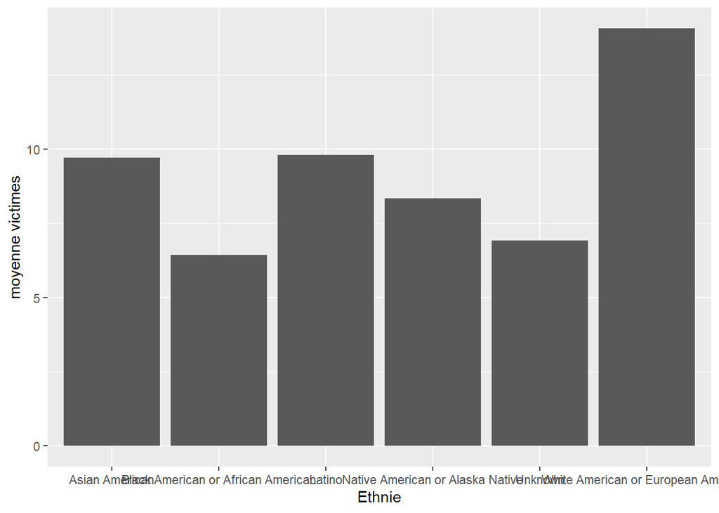

```r
plotdata <- dfr %>%
  group_by(Race) %>%
  summarize(mean_victim = mean(`Total victims`))

plotdata2 <- dfr %>%
  group_by(Race) %>%
  summarize(sum_victim = sum(`Total victims`))

ggplot(plotdata,
       aes(x = Race,
           y = mean_victim)) +
  geom_bar(stat = "identity")+
  labs(x = "Ethnie", y = "moyenne victimes")
```

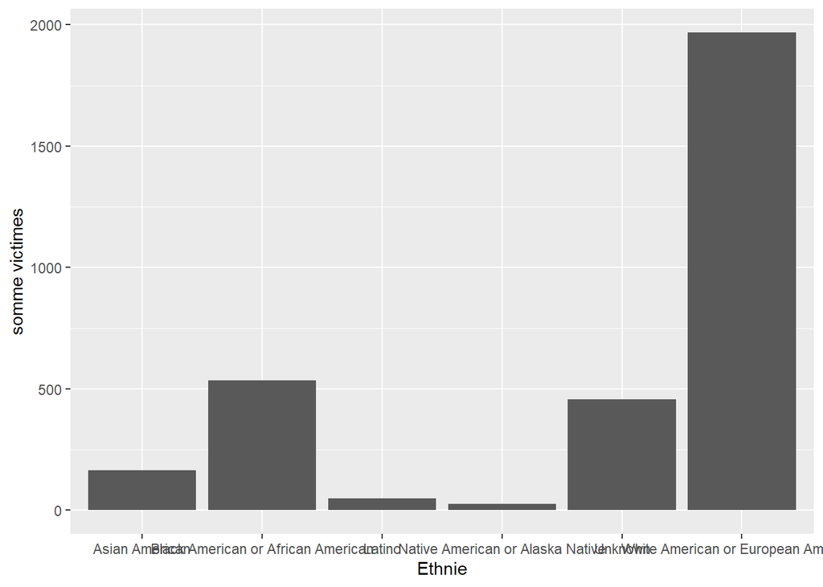

```r
ggplot(plotdata2,
       aes(x = Race,
           y = sum_victim)) +
  geom_bar(stat = "identity")+
  labs(x = "Ethnie", y = "somme victimes")
```

openClause / total victim

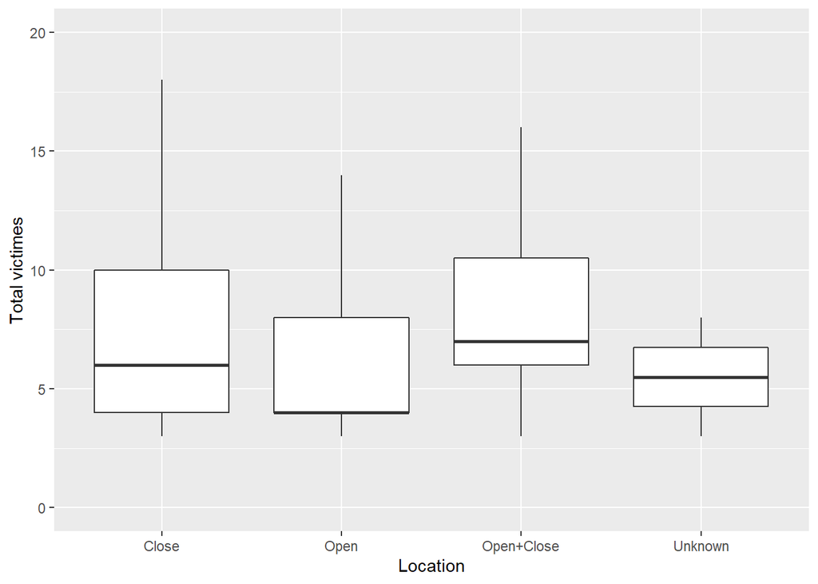

```r
ggplot(dfrClean, aes(x=dfrClean$`Open/Close Location`, y=dfrClean$`Total victims`)) +
   geom_boxplot(outlier.shape = NA) +
   coord_cartesian(ylim = c(0, 20))+
  labs(x = "Location", y = "Total victimes")
```

cause / total victims

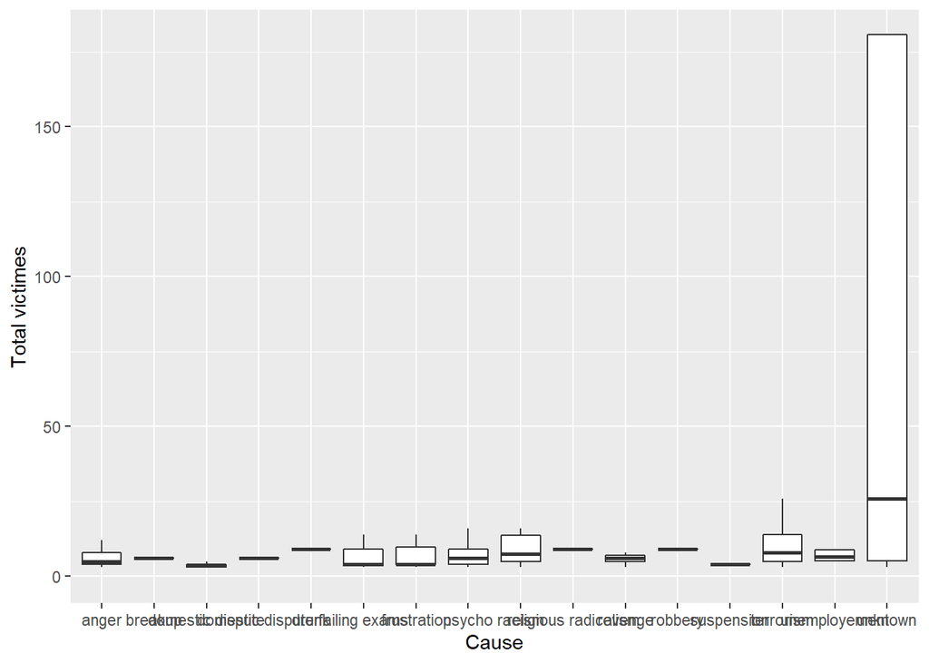

```r
ggplot(dfrClean, aes(x=dfrClean$Cause, y=dfrClean$`Total victims`)) +
   geom_boxplot(outlier.shape = NA) +
   coord_cartesian(ylim = c(0, 180))+
  labs(x = "Cause", y = "Total victimes")
```

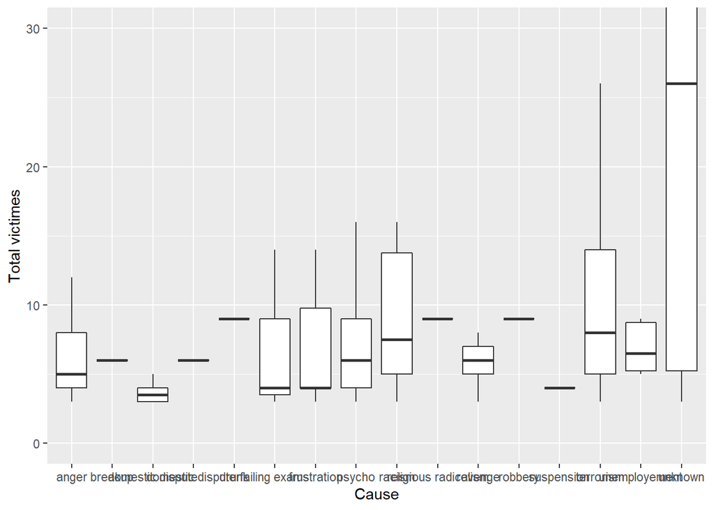

```r
ggplot(dfrClean, aes(x=dfrClean$Cause, y=dfrClean$`Total victims`)) +
   geom_boxplot(outlier.shape = NA) +
   coord_cartesian(ylim = c(0, 30))+
  labs(x = "Cause", y = "Total victimes")
```

age / nb victim

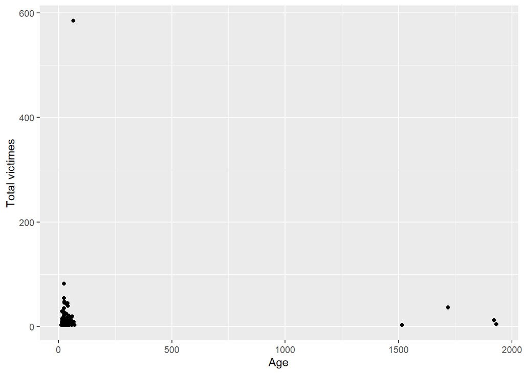

```r
ggplot(dfrClean,
       aes(x = dfrClean$Age,
           y = dfrClean$`Total victims`)) +
  geom_point()+
  labs(x = "Age", y = "Total victimes")
```

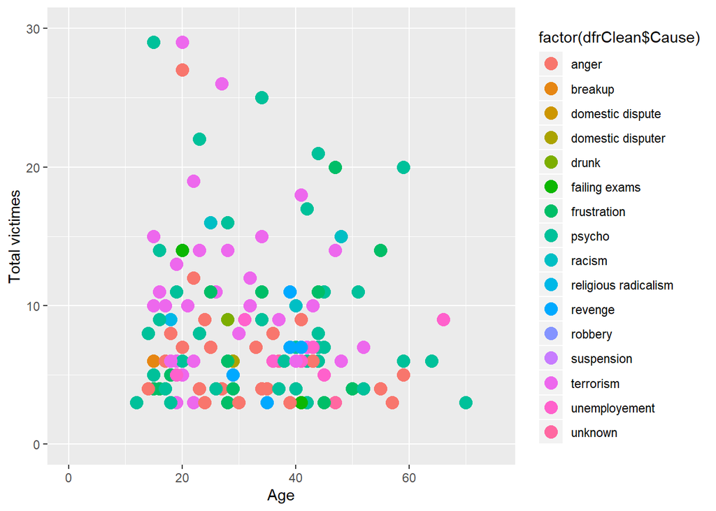

```r
ggplot(dfrClean,
       aes(x = dfrClean$Age,
           y = dfrClean$`Total victims`)) +
  geom_point(aes(colour = factor(dfrClean$Cause)), size = 4)+
  coord_cartesian(ylim = c(0, 30),xlim = c(0,75))+
  labs(x = "Age", y = "Total victimes")
```

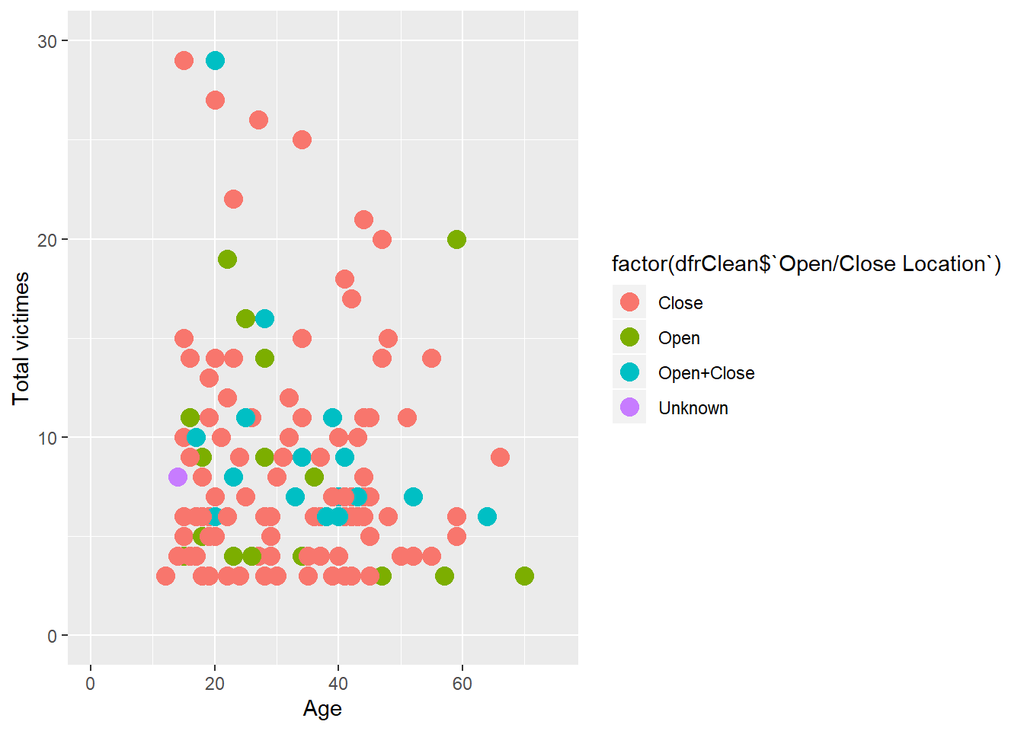

```r
ggplot(dfrClean,
       aes(x = dfrClean$Age,
           y = dfrClean$`Total victims`)) +
  geom_point(aes(colour = factor(dfrClean$`Open/Close Location`)), size = 4)+
  coord_cartesian(ylim = c(0, 30),xlim = c(0,75))+
  labs(x = "Age", y = "Total victimes")
```

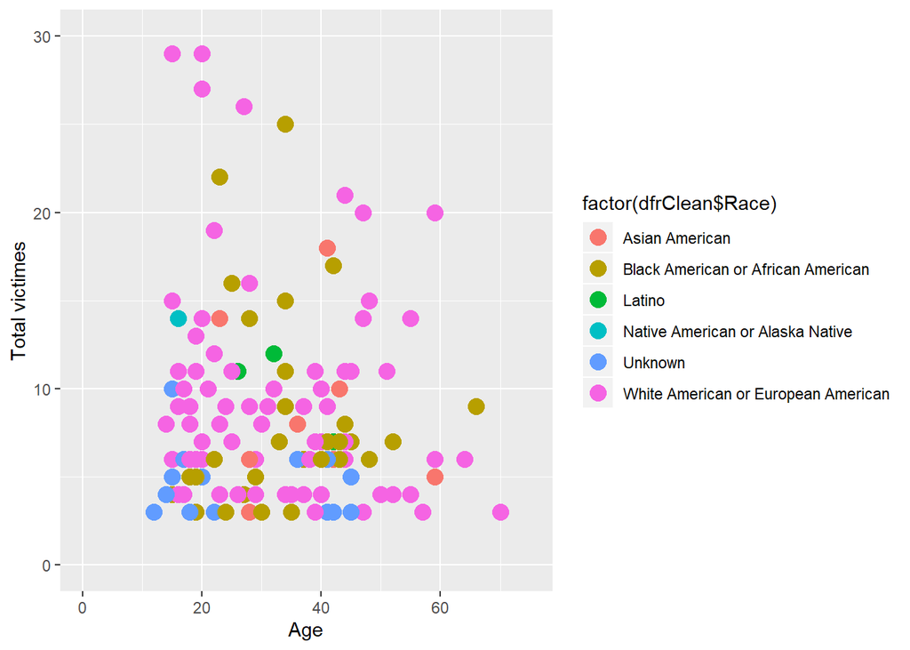

```r
ggplot(dfrClean,
       aes(x = dfrClean$Age,
           y = dfrClean$`Total victims`)) +
  geom_point(aes(colour = factor(dfrClean$Race)), size = 4)+
  coord_cartesian(ylim = c(0, 30),xlim = c(0,75))+
  labs(x = "Age", y = "Total victimes")
```

perform t-tests to compare pairwise the mean of the variable “Total victims” depending on two levels of some categorical variables (Mental Health issue or not, Male or Female, Open or Close Location, etc.). Same question with the variable “Age”.

```r
MHIyes <- dfr[dfr$`Mental Health Issues` == "Yes",]
MHIno <- dfr[dfr$`Mental Health Issues` == "No",]
Male <- dfr[dfr$Gender == "Male",]
Female <- dfr[dfr$Gender == "Female",]
open <- dfr[dfr$`Open/Close Location` == "Open" ,]
close <- dfr[dfr$`Open/Close Location` == "Close",]

t.test(MHIyes$`Total victims`,dfr$Age)
```

```
##
##  Welch Two Sample t-test
##
## data:  MHIyes$`Total victims` and dfr$Age
## t = -3.1936, df = 175.26, p-value = 0.001666
## alternative hypothesis: true difference in means is not equal to 0
## 95 percent confidence interval:
##  -109.01481  -25.73914
## sample estimates:
## mean of x mean of y
##  11.70874  79.08571
```

```r
t.test(MHIno$`Total victims`,dfr$Age)
```

```
##
##  Welch Two Sample t-test
##
## data:  MHIno$`Total victims` and dfr$Age
## t = -3.4258, df = 174.27, p-value = 0.0007644
## alternative hypothesis: true difference in means is not equal to 0
## 95 percent confidence interval:
##  -113.7539  -30.5934
## sample estimates:
## mean of x mean of y
##  6.912088 79.085714
```

```r
t.test(Male$`Total victims`,dfr$Age)
```

```
##
##  Welch Two Sample t-test
##
## data:  Male$`Total victims` and dfr$Age
## t = -3.235, df = 177.55, p-value = 0.001451
## alternative hypothesis: true difference in means is not equal to 0
## 95 percent confidence interval:
##  -110.2428  -26.7033
## sample estimates:
## mean of x mean of y
##  10.61268  79.08571
```

```r
t.test(Female$`Total victims`,dfr$Age)
```

```
##
##  Welch Two Sample t-test
##
## data:  Female$`Total victims` and dfr$Age
## t = -3.3912, df = 174.65, p-value = 0.0008606
## alternative hypothesis: true difference in means is not equal to 0
## 95 percent confidence interval:
##  -113.08964  -29.88179
## sample estimates:
## mean of x mean of y
##   7.60000  79.08571
```

```r
t.test(open$`Total victims`,dfr$Age)
```

```
##
##  Welch Two Sample t-test
##
## data:  open$`Total victims` and dfr$Age
## t = -2.9434, df = 211.99, p-value = 0.003608
## alternative hypothesis: true difference in means is not equal to 0
## 95 percent confidence interval:
##  -109.62584  -21.68483
## sample estimates:
## mean of x mean of y
##  13.43038  79.08571
```

```r
t.test(close$`Total victims`,dfr$Age)
```

```
##
##  Welch Two Sample t-test
##
## data:  close$`Total victims` and dfr$Age
## t = -3.3195, df = 174.51, p-value = 0.001098
## alternative hypothesis: true difference in means is not equal to 0
## 95 percent confidence interval:
##  -111.55229  -28.36321
## sample estimates:
## mean of x mean of y
##  9.127962 79.085714
```

Perform an ANOVA to compare the mean of the variable “Total victims” depending on all levels of some categorical variables. Same question with the variable “Age”.

```r
anovaCause <- aov(dfr$`Total victims` ~ dfr$Cause  , dfr)
anovaRace <- aov(dfr$`Total victims` ~ dfr$Race, dfr )
anovaOpenClose <- aov(dfr$`Total victims` ~ dfr$`Open/Close Location`,dfr)
anovaGender <- aov(dfr$`Total victims`~ dfr$Gender, dfr)

summary(anovaCause)
```

```
##              Df Sum Sq Mean Sq F value  Pr(>F)
## dfr$Cause    15  92066    6138   5.202 7.5e-09 ***
## Residuals   221 260732    1180
## ---
## Signif. codes:  0 '***' 0.001 '**' 0.01 '*' 0.05 '.' 0.1 ' ' 1
## 77 observations deleted due to missingness
```

```r
summary(anovaRace )
```

```
##              Df Sum Sq Mean Sq F value Pr(>F)
## dfr$Race      5   3984   796.7   0.682  0.638
## Residuals   308 360078  1169.1
```

```r
summary(anovaOpenClose )
```

```
##                            Df Sum Sq Mean Sq F value Pr(>F)
## dfr$`Open/Close Location`   3   1183   394.5   0.337  0.799
## Residuals                 310 362878  1170.6
```

```r
summary(anovaGender)
```

```
##              Df Sum Sq Mean Sq F value Pr(>F)
## dfr$Gender    3    738     246    0.21   0.89
## Residuals   310 363323    1172
```

```r
anovaCause2 <- aov(dfr$Age ~ dfr$Cause  , dfr)
anovaRace2 <- aov(dfr$Age ~ dfr$Race, dfr )
anovaOpenClose2 <- aov(dfr$Age ~ dfr$`Open/Close Location`,dfr)
anovaGender2 <- aov(dfr$Age~ dfr$Gender, dfr)

summary(anovaCause2)
```

```
##              Df   Sum Sq Mean Sq F value Pr(>F)
## dfr$Cause    13   770282   59252   0.743  0.718
## Residuals   140 11162191   79730
## 160 observations deleted due to missingness
```

```r
summary(anovaRace2 )
```

```
##              Df   Sum Sq Mean Sq F value Pr(>F)
## dfr$Race      5   115901   23180   0.293  0.917
## Residuals   169 13388599   79222
## 139 observations deleted due to missingness
```

```r
summary(anovaOpenClose2 )
```

```
##                            Df   Sum Sq Mean Sq F value Pr(>F)
## dfr$`Open/Close Location`   3    70852   23617   0.301  0.825
## Residuals                 171 13433648   78559
## 139 observations deleted due to missingness
```

```r
summary(anovaGender2)
```

```
##              Df   Sum Sq Mean Sq F value Pr(>F)
## dfr$Gender    3    18933    6311    0.08  0.971
## Residuals   171 13485566   78863
## 139 observations deleted due to missingness
```

Create a new table with the total of variables “Fatalities”, “Injured” and “Total victims” by year. Represent how these variables depend on the year (Scatterplots for each variable, Same scatterplot for the three variables, etc.).

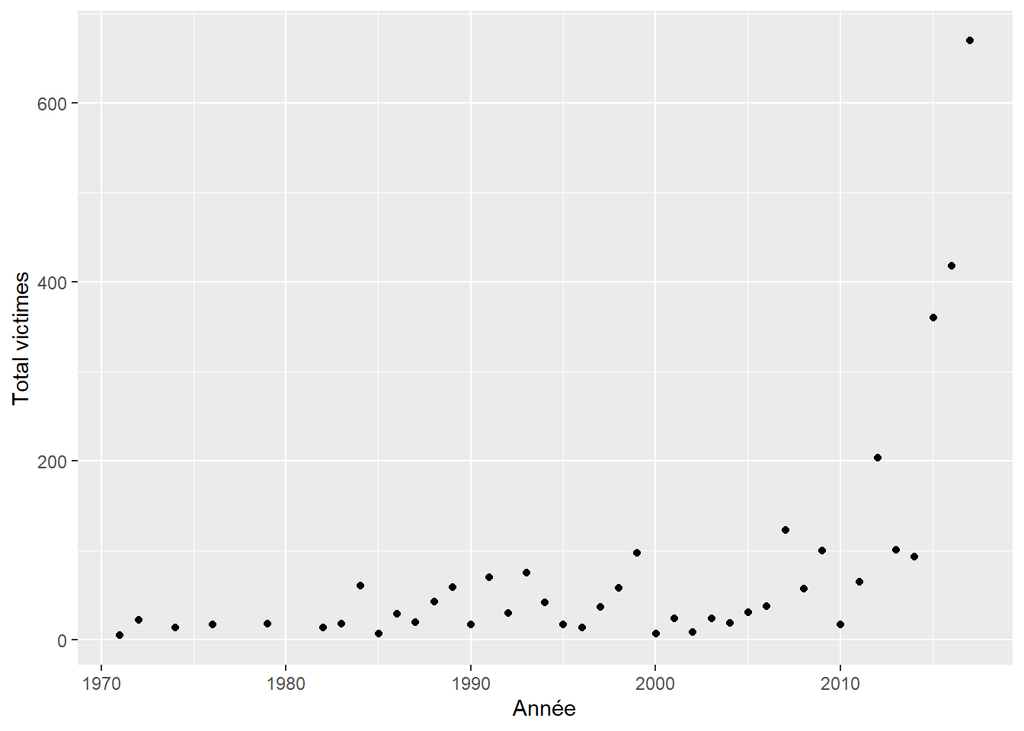

```r
FatalityByYear <- data.frame(matrix(ncol = 4, nrow = 0))
x <- c("Year", "Fatalities", "Injured","Total victims")
colnames(FatalityByYear) <- x

uniqueYear <-  unique(dfr$year)
uniqueYear<- uniqueYear[! uniqueYear %in% 66]

for(i in 1:length(uniqueYear))
{
  subsetDfr <- dfr[dfr$year == uniqueYear[i],]
  temp <- data.frame(uniqueYear[i],sum(subsetDfr$Fatalities), sum(subsetDfr$Injured), sum(subsetDfr$`Total victims`))
  names(temp)<-c("Year", "Fatalities", "Injured","Total victims")
  FatalityByYear <- rbind(FatalityByYear, temp)
}

FatalityByYear$Year <- as.Date(FatalityByYear$Year, format='%y')
ggplot(FatalityByYear,
       aes(x = FatalityByYear$Year,
           y = FatalityByYear$`Total victims`)) +
  geom_point()+
  labs(x = "Année", y = "Total victimes")
```

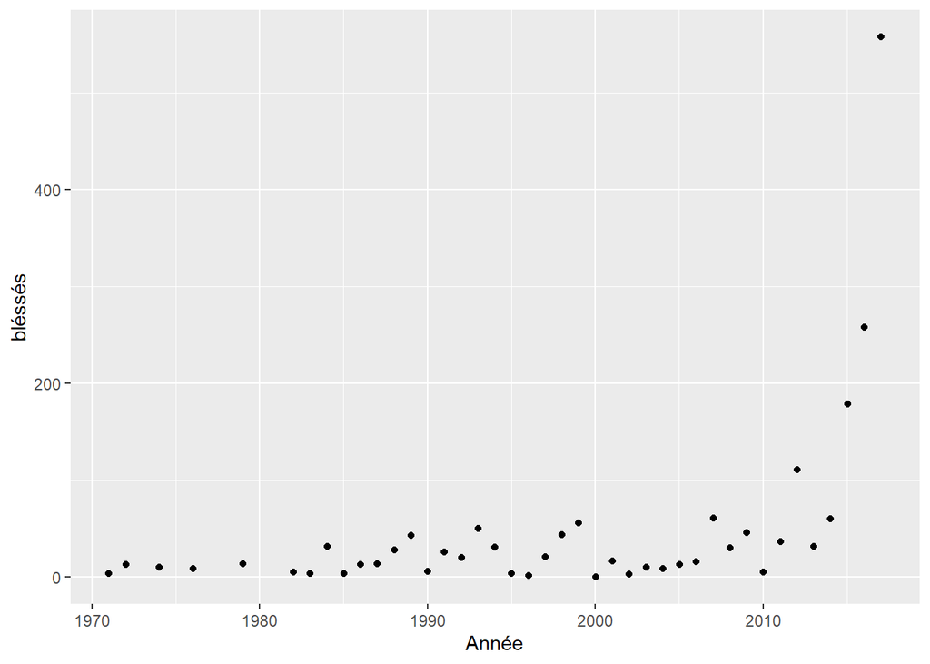

```r
ggplot(FatalityByYear,
       aes(x = FatalityByYear$Year,
           y = FatalityByYear$Injured)) +
  geom_point()+
  labs(x = "Année", y = "bléssés")
```

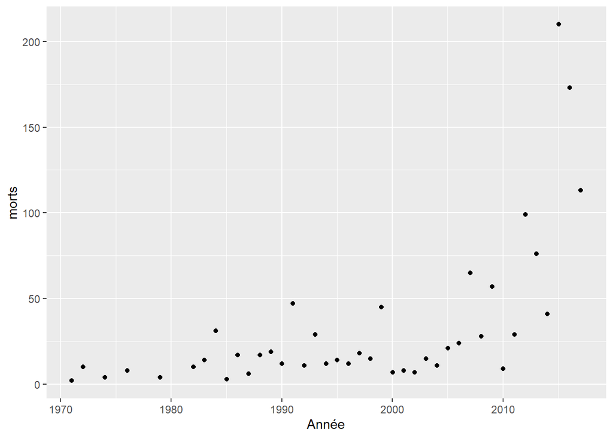

```r
ggplot(FatalityByYear,
       aes(x = FatalityByYear$Year,
           y = FatalityByYear$Fatalities)) +
  geom_point()+
  labs(x = "Année", y = "morts")
```

Use the previous table to perform a regression between the variable “Total victims” and the variable “Year”. Is a linear regression relevant? And an exponential one? Same questions starting in 2010. Make predictions.

une regression liéaire est utile jusqu’à 2008-2009 au dela des ces dates il faut une regression exponentiel car les chiffres augmentent selon un profil exponentiel.

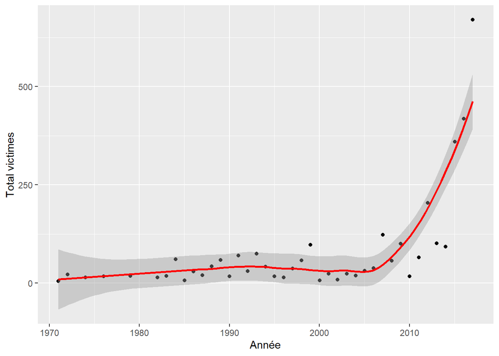

```r
ggplot(FatalityByYear,
       aes(x = FatalityByYear$Year,
           y = FatalityByYear$`Total victims`)) +
  geom_point()+
  geom_smooth(method='loess', formula= y~x,color="red")+
  labs(x = "Année", y = "Total victimes")
```

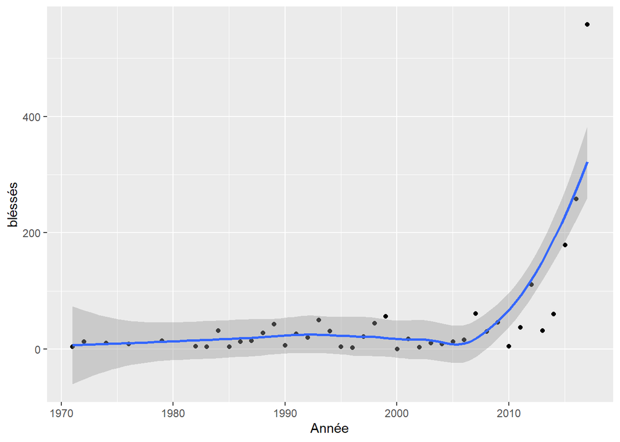

```r
ggplot(FatalityByYear,
       aes(x = FatalityByYear$Year,
           y = FatalityByYear$Injured)) +
  geom_point()+
  geom_smooth(method='loess', formula= y~x)+
  labs(x = "Année", y = "bléssés")
```

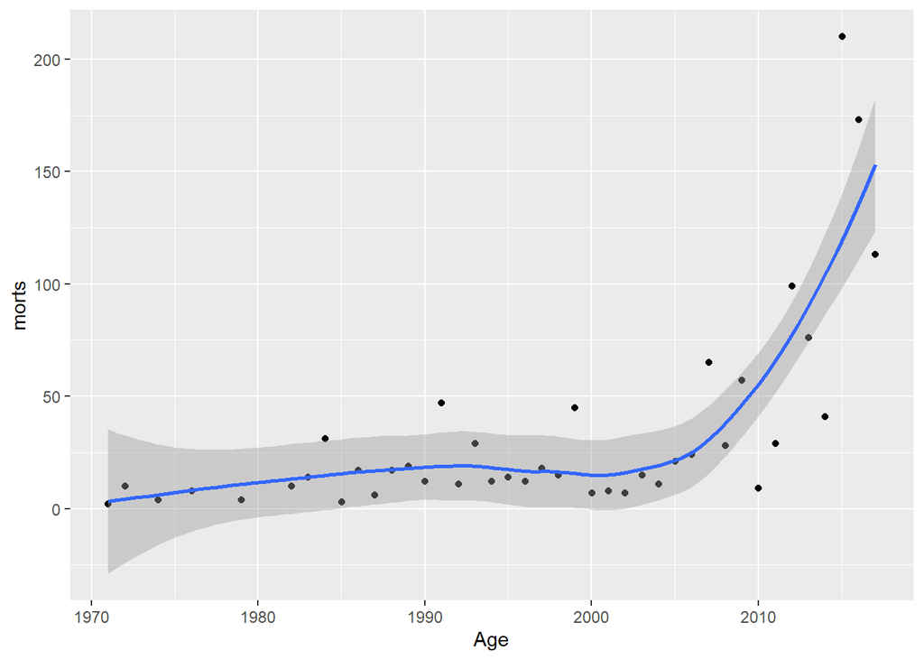

```r
ggplot(FatalityByYear,
       aes(x = FatalityByYear$Year,
           y = FatalityByYear$Fatalities)) +
  geom_point()+
  geom_smooth(method='loess', formula= y~x)+
  labs(x = "Age", y = "morts")
```

Use the variables “Longitude” and “Latitude” to draw a scatterplot with the US map in background. Documente yourself to do that. Make several versions.

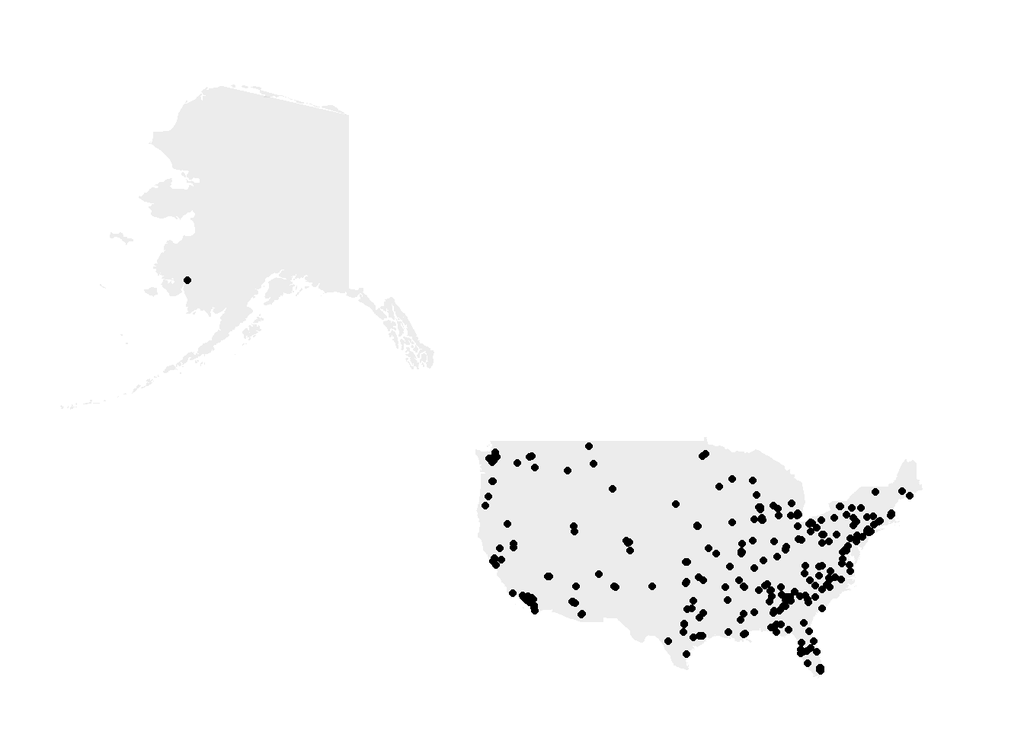

```r
library(maps)
 US <- map_data("world") %>% filter(region=="USA")

 ggplot() +
  geom_polygon(data = US, aes(x=US$long, y = US$lat, group = US$group), fill="grey", alpha=0.3) +
  geom_point(data=dfr, aes(x=as.numeric(dfr$Longitude), y=as.numeric(dfr$Latitude))) + ylim(24,71)+ xlim(-180,-60) +coord_map() +theme_void()
```

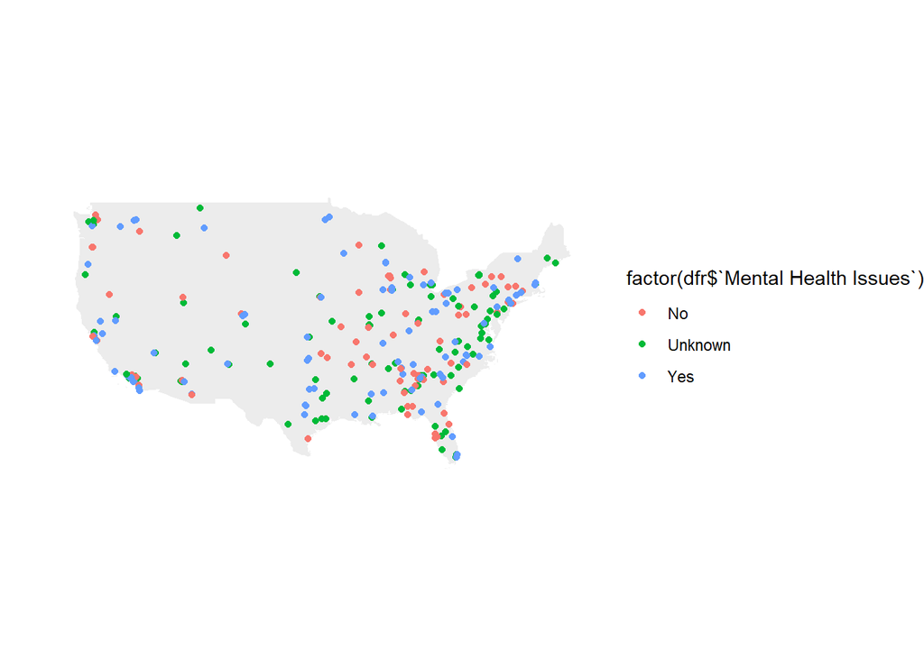

```r
  ggplot() +
  geom_polygon(data = US, aes(x=US$long, y = US$lat, group = US$group), fill="grey", alpha=0.3) +
  geom_point(data=dfr, aes( x=as.numeric(dfr$Longitude), y=as.numeric(dfr$Latitude),color=factor(dfr$`Mental Health Issues`))) + ylim(24,50)+ xlim(-130,-65) +coord_map() +theme_void()
```

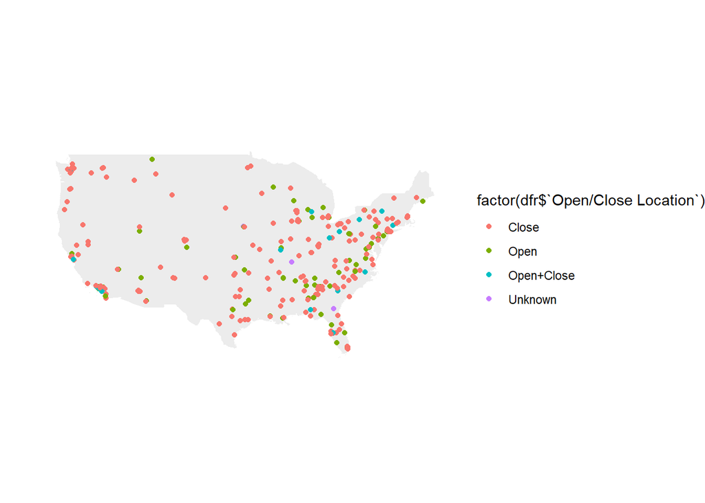

```r
    ggplot() +
  geom_polygon(data = US, aes(x=US$long, y = US$lat, group = US$group), fill="grey", alpha=0.3) +
  geom_point(data=dfr, aes( x=as.numeric(dfr$Longitude), y=as.numeric(dfr$Latitude),color=factor(dfr$`Open/Close Location`))) + ylim(24,50)+ xlim(-130,-65) +coord_map() +theme_void()
```

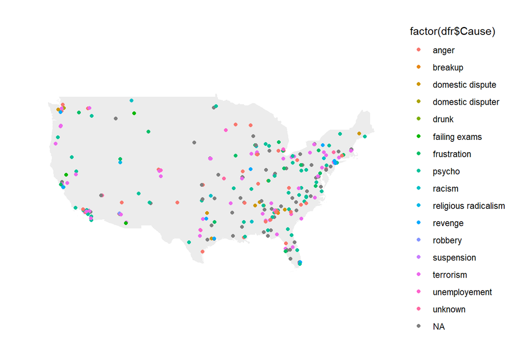

```r
      ggplot() +
  geom_polygon(data = US, aes(x=US$long, y = US$lat, group = US$group), fill="grey", alpha=0.3) +
  geom_point(data=dfr, aes( x=as.numeric(dfr$Longitude), y=as.numeric(dfr$Latitude),color=factor(dfr$Cause))) + ylim(24,50)+ xlim(-130,-65) +coord_map() +theme_void()
```

Bonus: make Choropleth maps to compare the different states.

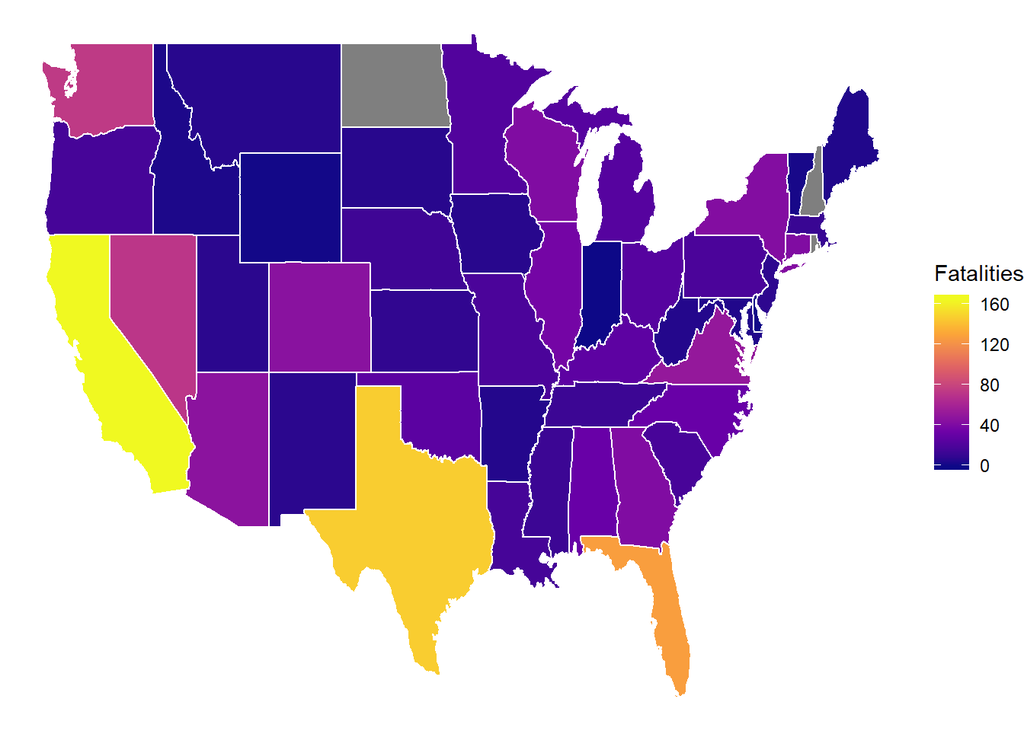

```r
TotalRegion <- data.frame(matrix(ncol = 5, nrow = 0))
x <- c("region", "Fatalities", "Injured","Total victims", "nb")
colnames(TotalRegion) <- x

uniqueRegion <-  unique(dfr$State)


for(i in 1:length(uniqueRegion))
{
  subsetDfr <- dfr[dfr$State == uniqueRegion[i],]
  temp <- data.frame(uniqueRegion[i],sum(subsetDfr$Fatalities), sum(subsetDfr$Injured), sum(subsetDfr$`Total victims`), nrow(subsetDfr))
  names(temp)<-c("region", "Fatalities", "Injured","Total victims","nb")
  TotalRegion <- rbind(TotalRegion, temp)
}

states_map <- map_data("state")


arrests_map <- left_join(states_map, TotalRegion, by = "region")
for(i in 1:nrow(TotalRegion)){
  for(j in 1:nrow(arrests_map)){
    if(tolower(arrests_map$region[j]) == tolower(TotalRegion$region[i])){
      arrests_map$Fatalities[j] <- TotalRegion$Fatalities[i]
      arrests_map$Injured[j] <- TotalRegion$Injured[i]
      arrests_map$`Total victims`[j] <- TotalRegion$`Total victims`[i]
      arrests_map$nb[j] <- TotalRegion$nb[i]
    }
  }
}

ggplot(arrests_map, aes(long, lat, group = group))+
  geom_polygon(aes(fill = Fatalities), color = "white")+
  scale_fill_viridis_c(option = "C")+ theme_void()
```